# Report - LDA Lab

Jose Munoz Angulo, Vivien Marcault, Baptiste Rigondaud

March 19, 2018

## Question a)

Creation of the labels:

```r
labels<-rep(1: 2, each=494/2)
set=sample(labels, 494)
```

Creation of the table that contains the continent of origin and the genetic markers:

```r
NAcont<-cbind(contID=contID,NAm2[,-(1:8)])
NAcont[,1]<-factor(NAcont[,1])
```

Computation of the lda:

```r
#lda(contID~., data=NAcont, subset=(set==1)) Does not work
```

Since some predictors seem to be constant in some classes (zero-variance), the computation of the LDA won’t be possible.

## Question b)

In order to peform such operation, we use the code below:

```r
withinvar<-apply(NAcont[(set==1),-1],FUN=function(x){tapply(x,NAcont[(set==1),1],FUN=var)},MARGIN=2)
bool<-as.logical(apply(withinvar,FUN=function(x){prod(x!=0)},MARGIN=2))
NAcont2<-cbind(contID=contID,(NAm2[,-(1:8)])[,bool])
NAcont2[,1]<-factor(NAcont[,1])

#Count the number of remaining markers
count <- length(NAcont2[1,])-1
```

The number of remaining markers is 2922. The markers that were removed from the model have a variance of zero for at least one continent. This means that there are markers that do not yield information since they are constant for every continent. Thus, there are not relevant for the model. However, since some of the markers that were removed are constant for only one continent, some information is lost.

In order to learn the model, we run:

```r
lda(contID~., data=NAcont2, subset=(set==1))
```

## Question c)

In order to predict the original populations of individuals who have not been trained, we use the following code:

```r
pre = predict(model, newdata=subset(NAcont[, -1], set==2),type="class")
pre$class
```

```
##   [1] NorthAmerica   NorthAmerica   SouthAmerica   NorthAmerica
##   [5] NorthAmerica   NorthAmerica   NorthAmerica   NorthAmerica
##   [9] NorthAmerica   NorthAmerica   NorthAmerica   NorthAmerica
##  [13] NorthAmerica   NorthAmerica   SouthAmerica   NorthAmerica
##  [17] CentralAmerica SouthAmerica   SouthAmerica   SouthAmerica
##  [21] SouthAmerica   NorthAmerica   SouthAmerica   CentralAmerica
##  [25] NorthAmerica   SouthAmerica   NorthAmerica   SouthAmerica
##  [29] SouthAmerica   SouthAmerica   NorthAmerica   SouthAmerica
##  [33] NorthAmerica   SouthAmerica   SouthAmerica   SouthAmerica
##  [37] SouthAmerica   SouthAmerica   SouthAmerica   SouthAmerica
##  [41] SouthAmerica   SouthAmerica   SouthAmerica   SouthAmerica
##  [45] SouthAmerica   SouthAmerica   SouthAmerica   SouthAmerica
##  [49] SouthAmerica   SouthAmerica   SouthAmerica   SouthAmerica
##  [53] SouthAmerica   SouthAmerica   SouthAmerica   SouthAmerica
##  [57] SouthAmerica   SouthAmerica   SouthAmerica   CentralAmerica
```

[output cut: 48 more lines]

## Question d)

Computation of the confusion matrix:

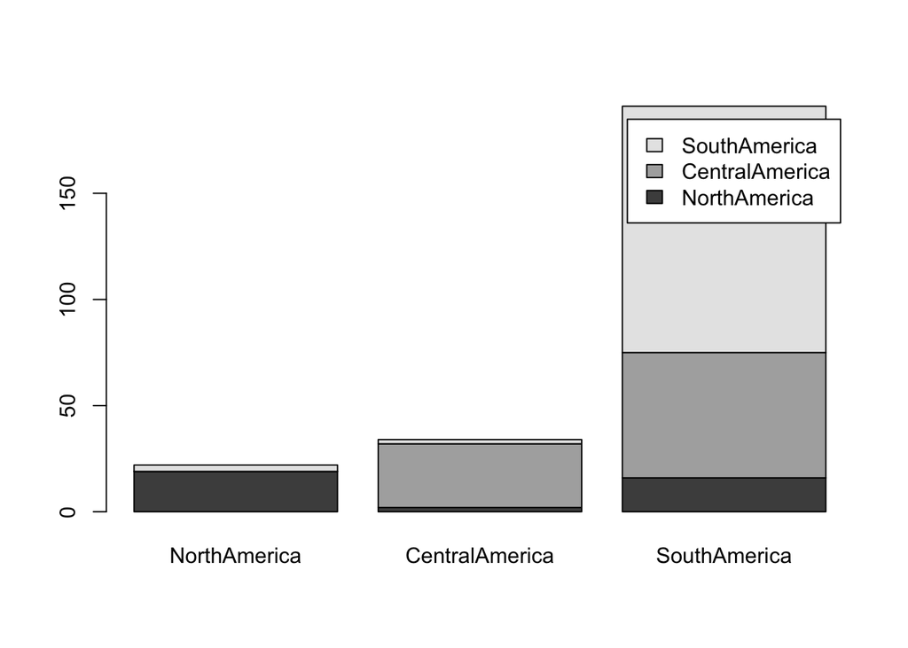

```r
confusion = table(subset(NAcont[, 1], set==2), pre$class)
barplot(confusion, legend.text=TRUE)
```

## Question e)

In order to compute the prediction error, we calculate by subtracting the number of well predicted values, i.e., the sum of the diagonal in the confusion matrix to the total number of samples used in the validation phase. This is the total value of mismatched samples. We divide the number of samples to the previously obtained value to calculate the mismatching ratio.

```r
error <- (sum(confusion) - sum(diag(confusion)))/sum(confusion)
error
```

```
## [1] 0.3319838
```

## Question f)

To improve the validation process, we propose to use a k-fold cross validation. We use the following code for the implementation.

```r
# K-fold cross validation.
k <- 10 # Number of folds
set <- set(494, k) # Set selection vector.
errors <- c()

for (i in 1:k) {
  # Remove markers
  withinvar<-apply(NAcont[(set!=i),-1],FUN=function(x){tapply(x,NAcont[(set!=i),1],FUN=var)},MARGIN=2)
  bool<-as.logical(apply(withinvar,FUN=function(x){prod(x!=0)},MARGIN=2))
  NAcont2<-cbind(contID=contID,(NAm2[,-(1:8)])[,bool])
  NAcont2[,1]<-factor(NAcont[,1])

  # Generate model
  model <- lda(contID~., data=NAcont2, subset=(set!=i))

  # Predict values
  pre <- predict(model, newdata=subset(NAcont[, -1], set == i),type="class")

  # Calculate error
  confusion <- table(subset(NAcont[, 1], set == i), pre$class)
  errors <- c(errors, (sum(confusion) - sum(diag(confusion)))/sum(confusion))
}

print(errors)
```

```
##  [1] 0.2083333 0.1020408 0.1800000 0.1400000 0.1041667 0.1836735 0.1800000
##  [8] 0.2000000 0.1800000 0.1800000
```

As we can observe using this method with 10 folds, the mean error, in this case 0.1658214, is less than the prediction error that we obtained before, proving that this is in fact an improvement over the classical approach.